# Trees

A decision tree is a non-parametric learning method used for both classification and regression. It works by recursively partitioning the feature space into a set of rectangular regions, based on splitting rules that minimize an impurity measure (such as Gini index, entropy, or residual sum of squares). Each split aims to create more homogeneous subgroups in terms of the outcome variable. This process continues until a stopping criterion is met (e.g., minimum node size or maximum depth), or the tree is pruned to avoid overfitting.

For categorical outcomes, the tree assigns the majority class of training observations within each region to new data.

For numeric outcomes, the tree predicts the mean of the response values in the region.

Among supervised machine learning models, decision trees are the easiest to understand. They are computationally efficient, automatically handle variable selection, can model non-linear relationships and handle qualitative predictors. However, Trees tend to overfit the data and generally underperform other supervised learning methods in prediction. These two issues can be addressed by selecting better model hyperparameters. Hyperparameter values are evaluated and the one with the lowest cross-validation error selected.

### Use Cases

- Classifying customers as likely to churn or not
- Predicting default risk in credit scoring
- Diagnosing diseases based on clinical indicators
- Fraud detection in banking transactions
- Predicting equipment failure from sensor data

### Strengths

- Easy to interpret and explain to others
- Requires minimal preprocessing
  - No need to standardize numeric features
  - Can handle many types of predictors (sparse, skewed, continuous, categorical, etc.)
  - Handles missing values without imputation
  - Robust to outliers
- Efficient
  - Only uses features that contribute to prediction performance
- Flexible
  - Handles non-linear relationships and interactions
- Feature Selection
  - implicitly conduct feature selection. If a predictor is never used in a split, then the prediction equation is independent of it. However, this advantage is weakened for highly correlated predictors where the choice of which is used for a split is somewhat random.

### Weaknesses:

- Less-than optimal predictive performance.
  - Tree models partition the predictor space into rectangular regions. If the relationship between predictors and outcome is not adequately described by these rectangles, performance will be poor.
  - Number of possible predicted outcomes is finite and is determined by the number of leaves. This limitation is unlikely to capture all the nuances of the data.
- Model instability
  - Slight changes in the data can drastically change the structure of the tree, hence the interpretation. Thus, these models have high variance. Easy to overfit train data.

### Overview

In this note, we will construct a classification tree to predict cancer, and another classification tree to predict who clicks on an ad. Next, we will construct a regression tree to predict price of a house using a dataset on California houess and then one using Seattle homes.

```python
import numpy as np
import pandas as pd
import matplotlib.pyplot as plt

from sklearn.model_selection import train_test_split
from sklearn.metrics import accuracy_score, roc_auc_score
```

## Classification Tree

### Data

```python
from sklearn.datasets import load_breast_cancer
X = load_breast_cancer().data
y = load_breast_cancer().target
data = pd.DataFrame(X, columns = load_breast_cancer()['feature_names']).assign(cancer = y)
data.head()
```

|  | mean radius | mean texture | mean perimeter | mean area | mean smoothness | mean compactness | mean concavity | mean concave points | mean symmetry | mean fractal dimension | ... | worst texture | worst perimeter | worst area | worst smoothness | worst compactness | worst concavity | worst concave points | worst symmetry | worst fractal dimension | cancer |
| --- | --- | --- | --- | --- | --- | --- | --- | --- | --- | --- | --- | --- | --- | --- | --- | --- | --- | --- | --- | --- | --- |
| 0 | 17.99 | 10.38 | 122.80 | 1001.0 | 0.11840 | 0.27760 | 0.3001 | 0.14710 | 0.2419 | 0.07871 | ... | 17.33 | 184.60 | 2019.0 | 0.1622 | 0.6656 | 0.7119 | 0.2654 | 0.4601 | 0.11890 | 0 |
| 1 | 20.57 | 17.77 | 132.90 | 1326.0 | 0.08474 | 0.07864 | 0.0869 | 0.07017 | 0.1812 | 0.05667 | ... | 23.41 | 158.80 | 1956.0 | 0.1238 | 0.1866 | 0.2416 | 0.1860 | 0.2750 | 0.08902 | 0 |
| 2 | 19.69 | 21.25 | 130.00 | 1203.0 | 0.10960 | 0.15990 | 0.1974 | 0.12790 | 0.2069 | 0.05999 | ... | 25.53 | 152.50 | 1709.0 | 0.1444 | 0.4245 | 0.4504 | 0.2430 | 0.3613 | 0.08758 | 0 |
| 3 | 11.42 | 20.38 | 77.58 | 386.1 | 0.14250 | 0.28390 | 0.2414 | 0.10520 | 0.2597 | 0.09744 | ... | 26.50 | 98.87 | 567.7 | 0.2098 | 0.8663 | 0.6869 | 0.2575 | 0.6638 | 0.17300 | 0 |
| 4 | 20.29 | 14.34 | 135.10 | 1297.0 | 0.10030 | 0.13280 | 0.1980 | 0.10430 | 0.1809 | 0.05883 | ... | 16.67 | 152.20 | 1575.0 | 0.1374 | 0.2050 | 0.4000 | 0.1625 | 0.2364 | 0.07678 | 0 |

5 rows × 31 columns

### Split Data

Use stratified sampling to split the data into train and test. Stratified sampling is particularly important in this case because the classes are unbalanced.

```python
X_train, X_test, y_train, y_test = train_test_split(X,y,
                                                    test_size=0.3,
                                                    stratify=y,
                                                    random_state=617)
```

### Fit Model

```python
from sklearn.tree import DecisionTreeClassifier, plot_tree
tree = DecisionTreeClassifier(random_state=617,
                              max_depth = 3) # by DecisionTreeClassifier will fit a maximal tree
tree.fit(X_train,y_train)
```

```
DecisionTreeClassifier(max_depth=3, random_state=617)
```

### Predict

We are making two kinds of predictions:

- Class predictions: Classify cases as 0 or 1.
- Probability predictions: Estimate probability (or likelihood) of each class.

```python
pred_train = tree.predict(X_train)
pred_test = tree.predict(X_test)

pred_train_prob = tree.predict_proba(X_train)
pred_test_prob = tree.predict_proba(X_test)
```

### Evaluate Model Performance

- Accuracy: Proportion of correct predictions
- AUC: Area under the ROC curve

We are looking for high accuracy and AUC. Also, looking for a small gap between training and test performance.

```python
print('Accuracy Train: ',accuracy_score(y_train, pred_train)) # same as tree.score(X_train, y_train)
print('Accuracy Test: ', accuracy_score(y_test, pred_test)) # same as tree.score(X_test, y_test)
print('AUC Train: ', roc_auc_score(y_train, pred_train_prob[:,1]))
print('AUC Test: ', roc_auc_score(y_test, pred_test_prob[:,1]))
```

```
Accuracy Train:  0.9773869346733668
Accuracy Test:  0.9239766081871345
AUC Train:  0.9797162162162163
AUC Test:  0.8879964953271028
```

### Inference

Visual representations of trees are powerful tools for understanding how the model makes decisions

- Feature importance: Most influential features appear near the top of the tree. Features used in earlier splits typically have a greater impact on prediction.
- Decision Rules: The tree explicitly shows rules used to split the data
- Structure: Tree represents the order in which features were considered and captures effects of combinations of features
- Cutoff values: Thresholds in the nodes represent key break points
- Leaf: Terminal nodes or leaves contain predictions
- Complexity: Depth of tree and number of nodes represent complexity of the tree model
- Leaf or Node Size: The number of observations in a node or leaf may represent the practical importance of the feature or cut-value

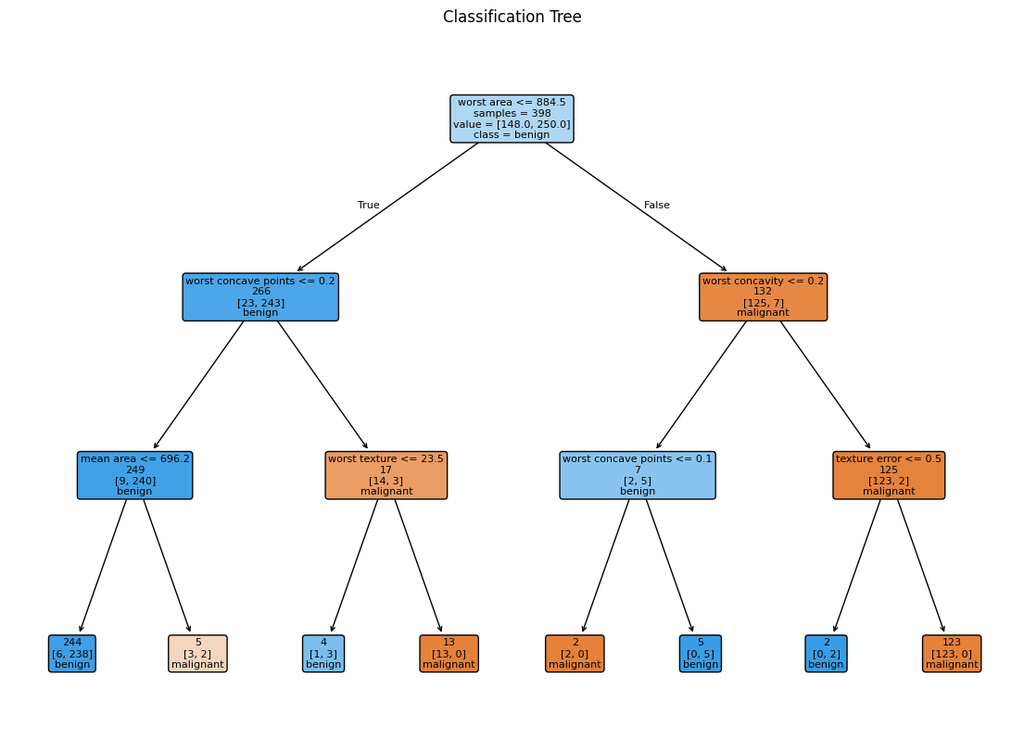

```python
plt.figure(figsize=(14, 10), facecolor='white')
#simple_tree = DecisionTreeClassifier(max_depth=3, random_state=617)
#simple_tree.fit(X_train,y_train)
plot_tree(tree,
          feature_names=load_breast_cancer().feature_names,
          class_names=load_breast_cancer().target_names,
          filled=True,
          label='root',
          impurity=False,
          fontsize=8,
          rounded = True,
          precision = 1,
          max_depth = 3)
plt.title('Classification Tree')
plt.show()
```

## Classification Tree

### … Clicks Data

This dataset describes user interactions with online advertisements for a digital marketing platform. It includes demographic, behavioral, and contextual features for 2000 users, along with whether each user clicked on an ad. The goal is to predict whether a person clicked on an ad.

Variable Description

### Read Data

- Import data
- Separate Features from the Outcome, click

```python
clicks = pd.read_csv('clicks.csv')
clicks.head()
```

|  | click | age | gender | device | browser | time_on_site | pages_visited | ad_position | ad_type | is_weekend | user_logged_in | past_click_rate | ad_relevance_score |
| --- | --- | --- | --- | --- | --- | --- | --- | --- | --- | --- | --- | --- | --- |
| 0 | 0 | 50 | 2 | 2 | 1 | 211 | 1 | 3 | 4 | 1 | 1 | 0.069 | 7 |
| 1 | 0 | 57 | 1 | 1 | 3 | 251 | 4 | 2 | 3 | 0 | 1 | 0.043 | 6 |
| 2 | 1 | 68 | 1 | 1 | 2 | 222 | 2 | 2 | 1 | 0 | 1 | 0.073 | 9 |
| 3 | 0 | 30 | 2 | 2 | 1 | 206 | 2 | 1 | 1 | 0 | 1 | 0.147 | 4 |
| 4 | 0 | 60 | 2 | 1 | 2 | 183 | 6 | 2 | 3 | 0 | 1 | 0.183 | 5 |

```python
X = clicks.drop(['click'], axis=1)
y = clicks.click
```

### Split Data

```python
from sklearn.model_selection import train_test_split
X_train_raw, X_test_raw, y_train, y_test = train_test_split(X,y,
                                                    train_size=0.7,
                                                    random_state=617)
```

### Transform

- Nominal categorical features need to transformed before use in a predictive model.
- Each categorical feature with k levels is represented by k-1 dummy variables.

```python
X_train_raw.head()
```

|  | age | gender | device | browser | time_on_site | pages_visited | ad_position | ad_type | is_weekend | user_logged_in | past_click_rate | ad_relevance_score |
| --- | --- | --- | --- | --- | --- | --- | --- | --- | --- | --- | --- | --- |
| 1086 | 63 | 2 | 1 | 4 | 126 | 6 | 1 | 1 | 1 | 0 | 0.133 | 5 |
| 1162 | 47 | 2 | 1 | 1 | 203 | 8 | 2 | 4 | 1 | 1 | 0.076 | 5 |
| 1736 | 25 | 2 | 2 | 1 | 189 | 3 | 1 | 4 | 0 | 1 | 0.198 | 6 |
| 682 | 54 | 1 | 1 | 2 | 208 | 6 | 2 | 4 | 0 | 0 | 0.001 | 5 |
| 2 | 68 | 1 | 1 | 2 | 222 | 2 | 2 | 1 | 0 | 1 | 0.073 | 9 |

```python
categorical_features = ['gender', 'device', 'browser','ad_position', 'ad_type','is_weekend', 'user_logged_in']

X_train = pd.get_dummies(X_train_raw,
                         columns=categorical_features,
                         drop_first=True)

X_test = pd.get_dummies(X_test_raw,
                        columns=categorical_features,
                        drop_first=True).reindex(columns=X_train.columns, fill_value=0)

X_train.head()
```

|  | age | time_on_site | pages_visited | past_click_rate | ad_relevance_score | gender_2 | gender_3 | device_2 | device_3 | browser_2 | browser_3 | browser_4 | browser_5 | ad_position_2 | ad_position_3 | ad_type_2 | ad_type_3 | ad_type_4 | is_weekend_1 | user_logged_in_1 |
| --- | --- | --- | --- | --- | --- | --- | --- | --- | --- | --- | --- | --- | --- | --- | --- | --- | --- | --- | --- | --- |
| 1086 | 63 | 126 | 6 | 0.133 | 5 | True | False | False | False | False | False | True | False | False | False | False | False | False | True | False |
| 1162 | 47 | 203 | 8 | 0.076 | 5 | True | False | False | False | False | False | False | False | True | False | False | False | True | True | True |
| 1736 | 25 | 189 | 3 | 0.198 | 6 | True | False | True | False | False | False | False | False | False | False | False | False | True | False | True |
| 682 | 54 | 208 | 6 | 0.001 | 5 | False | False | False | False | True | False | False | False | True | False | False | False | True | False | False |
| 2 | 68 | 222 | 2 | 0.073 | 9 | False | False | False | False | True | False | False | False | True | False | False | False | False | False | True |

### Fit Model

```python
from sklearn.tree import DecisionTreeClassifier, plot_tree
tree = DecisionTreeClassifier(random_state=617,
                             max_depth = 3) # By default DecisionTreeClassifier will fit a maximal tree
tree.fit(X_train,y_train)
```

```
DecisionTreeClassifier(max_depth=3, random_state=617)
```

### Predict

We are making two kinds of predictions:

- Class predictions: Classify cases as 0 or 1.
- Probability predictions: Estimate probability (or likelihood) of each class.

```python
pred_train = tree.predict(X_train)
pred_test = tree.predict(X_test)

pred_train_prob = tree.predict_proba(X_train)
pred_test_prob = tree.predict_proba(X_test)
```

### Evaluate Model Performance

- Accuracy: Proportion of correct predictions
- AUC: Area under the ROC curve

We are looking for high accuracy and AUC. Also, looking for a small gap between training and test performance.

```python
print('Accuracy Train: ',accuracy_score(y_train, pred_train)) # same as tree.score(X_train, y_train)
print('Accuracy Test: ', accuracy_score(y_test, pred_test)) # same as tree.score(X_test, y_test)
print('AUC Train: ', roc_auc_score(y_train, pred_train_prob[:,1]))
print('AUC Test: ', roc_auc_score(y_test, pred_test_prob[:,1]))
```

```
Accuracy Train:  0.7307142857142858
Accuracy Test:  0.6916666666666667
AUC Train:  0.7382857827859026
AUC Test:  0.6703806031811609
```

### Inference

Visual representations of trees are powerful tools for understanding how the model makes decisions

- Feature importance: Most influential features appear near the top of the tree. Features used in earlier splits typically have a greater impact on prediction.
- Decision Rules: The tree explicitly shows rules used to split the data
- Structure: Tree represents the order in which features were considered and captures effects of combinations of features
- Cutoff values: Thresholds in the nodes represent key break points
- Leaf: Terminal nodes or leaves contain predictions
- Complexity: Depth of tree and number of nodes represent complexity of the tree model
- Leaf or Node Size: The number of observations in a node or leaf may represent the practical importance of the feature or cut-value

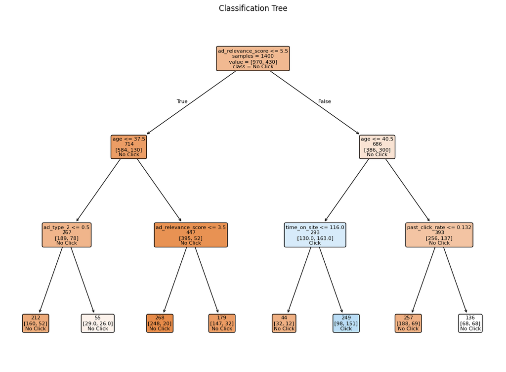

```python
from sklearn.tree import DecisionTreeClassifier

plt.figure(figsize=(14, 10), facecolor='white')
plot_tree(tree,
          feature_names=X_train.columns,
          class_names=['No Click','Click'],
          filled=True,
          label='root',
          impurity=False,
          fontsize=8,
          rounded = True)
plt.title('Classification Tree')
plt.show()
```

## Regression Tree

### … California Housing

```python
from sklearn.datasets import fetch_california_housing
X = fetch_california_housing().data
y = fetch_california_housing().target
pd.DataFrame(X, columns =  fetch_california_housing()['feature_names']).assign(Home_Value = y)
```

|  | MedInc | HouseAge | AveRooms | AveBedrms | Population | AveOccup | Latitude | Longitude | Home_Value |
| --- | --- | --- | --- | --- | --- | --- | --- | --- | --- |
| 0 | 8.3252 | 41.0 | 6.984127 | 1.023810 | 322.0 | 2.555556 | 37.88 | -122.23 | 4.526 |
| 1 | 8.3014 | 21.0 | 6.238137 | 0.971880 | 2401.0 | 2.109842 | 37.86 | -122.22 | 3.585 |
| 2 | 7.2574 | 52.0 | 8.288136 | 1.073446 | 496.0 | 2.802260 | 37.85 | -122.24 | 3.521 |
| 3 | 5.6431 | 52.0 | 5.817352 | 1.073059 | 558.0 | 2.547945 | 37.85 | -122.25 | 3.413 |
| 4 | 3.8462 | 52.0 | 6.281853 | 1.081081 | 565.0 | 2.181467 | 37.85 | -122.25 | 3.422 |
| ... | ... | ... | ... | ... | ... | ... | ... | ... | ... |
| 20635 | 1.5603 | 25.0 | 5.045455 | 1.133333 | 845.0 | 2.560606 | 39.48 | -121.09 | 0.781 |
| 20636 | 2.5568 | 18.0 | 6.114035 | 1.315789 | 356.0 | 3.122807 | 39.49 | -121.21 | 0.771 |
| 20637 | 1.7000 | 17.0 | 5.205543 | 1.120092 | 1007.0 | 2.325635 | 39.43 | -121.22 | 0.923 |
| 20638 | 1.8672 | 18.0 | 5.329513 | 1.171920 | 741.0 | 2.123209 | 39.43 | -121.32 | 0.847 |
| 20639 | 2.3886 | 16.0 | 5.254717 | 1.162264 | 1387.0 | 2.616981 | 39.37 | -121.24 | 0.894 |

20640 rows × 9 columns

### Split Data

- Split the data into train and test, placing 30% in the test sample.
- Using stratified sampling based on binned values of the outcome

```python
y_binned = pd.qcut(y, q=20)
X_train, X_test, y_train, y_test = train_test_split(X,y,
                                                    test_size=0.3,
                                                    random_state=617,
                                                    stratify=y_binned)
```

### Fit Model

```python
from sklearn.tree import DecisionTreeRegressor, plot_tree
from sklearn.metrics import root_mean_squared_error
tree = DecisionTreeRegressor(random_state=617,
                             max_depth = 3)  # Default is a maximal tree
tree.fit(X_train,y_train)
```

```
DecisionTreeRegressor(max_depth=3, random_state=617)
```

### Predict

- For a regression tree, predictions are numeric.
- Unlike linear regression, predictions from trees tend to have a relatively small number of unique values.
- The number of unique predictions is also the same as the number of leaves in the visual representation of the tree.

```python
pred_train = tree.predict(X_train)
pred_test = tree.predict(X_test)

print('First five predictions ', pred_train[:5])

print('Total Number of Unique Predictions: ', pd.Series(pred_train).unique())
```

```
First five predictions  [1.29584729 1.91585009 1.29584729 1.91585009 1.29584729]
Total Number of Unique Predictions:  [1.29584729 1.91585009 2.82736209 2.59998563 3.46831421 4.58532413
 1.91137352 3.74365326]
```

### Evalute Model Performance

- RMSE: Compares true value ot the predicted value. Smaller the value of RMSE, better the model
- Overfitting: Difference between RMSE of train and test samples reflect potential overfitting

```python
print('Train RMSE:', root_mean_squared_error(y_train, pred_train))
print('Test RMSE: ', root_mean_squared_error(y_test, pred_test))
```

```
Train RMSE: 0.7882307167397112
Test RMSE:  0.7908869442537659
```

### Inference

Visual representations of trees are powerful tools for understanding how the model makes decisions

- Feature importance: Most influential features appear near the top of the tree. Features used in earlier splits typically have a greater impact on prediction.
- Decision Rules: The tree explicitly shows rules used to split the data
- Structure: Tree represents the order in which features were considered and captures effects of combinations of features
- Cutoff values: Thresholds in the nodes represent key break points
- Leaf: Terminal nodes or leaves contain predictions
- Complexity: Depth of tree and number of nodes represent complexity of the tree model
- Leaf or Node Size: The number of observations in a node or leaf may represent the practical importance of the feature or cut-value

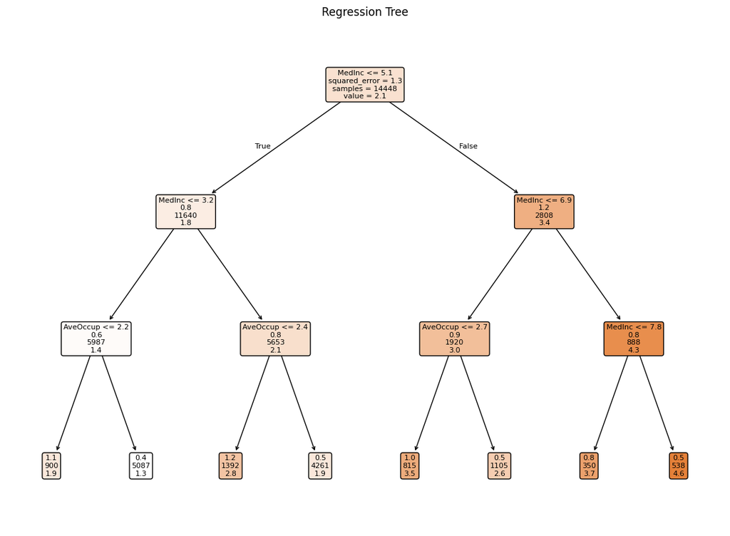

```python
plt.figure(figsize=(14, 10))
plot_tree(tree,
          feature_names=fetch_california_housing().feature_names,
          label = 'root',
          filled=True,
          fontsize=8,
          rounded = True,
          precision = 1,
          node_ids=False)
plt.title("Regression Tree")
plt.show()
```

## Regression Tree

### … House Sales

The data contains characteristics of houses and sales price for over 20,000 houses in the Seattle area (King County, WA) from May 2014 to May 2015. The goal of this assignment is to select useful features to use for prediction.

Variables

- id: Sales ID
- price: Sale price
- bedrooms: Number of bedrooms
- bathrooms: Number of bathrooms
- sqft_living: Area (in square feet) of the living area
- sqft_lot: Area (in square feet) of the land house is on
- floors: Number of floors (levels) in house
- waterfront: Whether the house has a view of the waterfront (0: No, 1: Yes)
- view: Rating of quality fo view (0-4)
- condition: Condition of the house (1-5, higher number indicates better condition)
- grade: Grade given to the housing unit, based on King County grading system (1-13, higher number indicates better grade)
- sqft_above: Area (in square feet) apart from basement
- sqft_basement: Area (in square feet) of the basement
- yr_built: Year the house was built
- yr_renovated: Year when house was renovated
- age: Age of house in years at time of sale

### Read Data

```python
houses = pd.read_csv('houses.csv')
X = houses.drop(['id','price','yr_built','yr_renovated'], axis = 1)
y = houses.price
```

### Split

```python
from sklearn.model_selection import train_test_split
y_binned = pd.qcut(y, q = 100)
X_train, X_test, y_train, y_test = train_test_split(X, y,
                 train_size = 0.7,
                 random_state = 617)
```

### Fit

```python
from sklearn.tree import DecisionTreeRegressor, plot_tree
tree = DecisionTreeRegressor(random_state=617,
                            max_depth=3)  # Default is a maximal tree
tree.fit(X_train, y_train)
```

```
DecisionTreeRegressor(max_depth=3, random_state=617)
```

### Predict

- For a regression tree, predictions are numeric.
- Unlike linear regression, predictions from trees tend to have a relatively small number of unique values.
- The number of unique predictions is also the same as the number of leaves in the visual representation of the tree.

```python
pred_train = tree.predict(X_train)
pred_test = tree.predict(X_test)
```

### Evalute Model Performance

- RMSE: Compares true value ot the predicted value. Smaller the value of RMSE, better the model
- Overfitting: Difference between RMSE of train and test samples reflect potential overfitting

```python
print('Train RMSE:', root_mean_squared_error(y_train, pred_train))
print('Test RMSE: ', root_mean_squared_error(y_test, pred_test))
```

```
Train RMSE: 243379.40639549663
Test RMSE:  245613.96549196943
```

### Inference

Visual representations of trees are powerful tools for understanding how the model makes decisions

- Feature importance: Most influential features appear near the top of the tree. Features used in earlier splits typically have a greater impact on prediction.
- Decision Rules: The tree explicitly shows rules used to split the data
- Structure: Tree represents the order in which features were considered and captures effects of combinations of features
- Cutoff values: Thresholds in the nodes represent key break points
- Leaf: Terminal nodes or leaves contain predictions
- Complexity: Depth of tree and number of nodes represent complexity of the tree model
- Leaf or Node Size: The number of observations in a node or leaf may represent the practical importance of the feature or cut-value

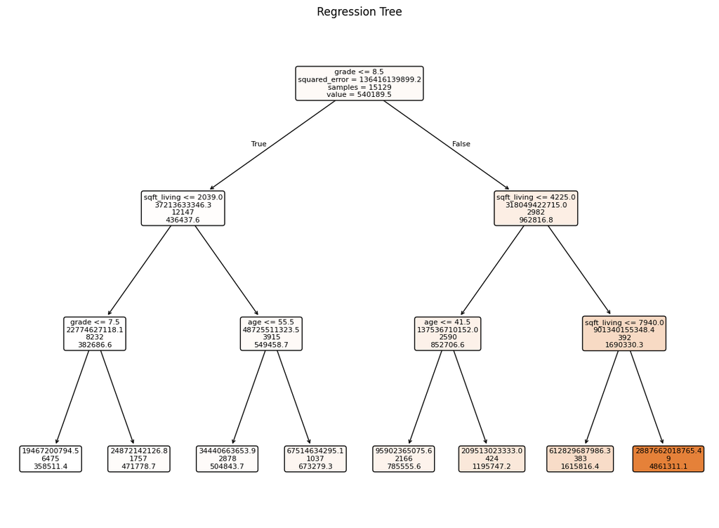

```python
plt.figure(figsize=(14, 10))
plot_tree(tree,
          feature_names=X.columns,
          label = 'root',
          filled=True,
          fontsize=8,
          rounded = True,
          precision = 1,
          node_ids=False)
plt.title("Regression Tree")
plt.show()
```

## Summary

This note demonstrated the use of classification trees to predict cancer and ad clicking behavior, and use of regression trees to predict home prices.

```python
import platform
from IPython.display import display, HTML
import matplotlib
import sklearn as sklearn_complete
text = ('This file was generated using Python ' + platform.python_version() +\
      ' on a ' + platform.platform() + \
      ' system with Pandas ' + pd.__version__ + \
      ', Numpy ' + np.__version__ + \
      ', Matplotlib ' + matplotlib.__version__ + \
      ', Scikit-Learn ' + sklearn_complete.__version__ )

html = f"""
<hr style="border: 0; height: 1px; background: lightgray;" />
<p style="font-size: x-small; color: #555;">{text}</p>
"""

display(HTML(html))
```

This file was generated using Python 3.13.5 on a Windows-10-10.0.19045-SP0 system with Pandas 2.3.0, Numpy 2.3.1, Matplotlib 3.10.3, Scikit-Learn 1.7.1